# Influence of Different Factors on Flight Delays in the Period of 1992-2004

## Investigation Overview

In this investigation we're looking at how the flight delays changed within 12 years (picking up 3 years) and what influences on them. We also want to verify the hypothesis if the predicted flight duration has been overestimated in later years (see [1]), which led to 'virtual' decrease of delays.

## Dataset Overview

We have flight databases for 1992 (5020651 entries), 1998 (5227051 entries) and 2004 (6987729 entries) for the USA. The following characteristics are taken in account:

- `Total delay` which is a sum of `Arrival delay` and `Departure delay` in minutes
- `Distance` in miles
- `CRS elapsed time` in minutes
- `Month` (between 1...12)

## Distribution of Total Delay

- `Total delay` averaged per `Flight Number` has unimodal distribution with no evident symmetry
- the mode of the `Total delay` slightly increased with years
- the distribution has heavy tails, especially for 1998 and 2004, which means that in 1992 **99% of flights** were delayed only up to **30 minutes**, in 1998 and 2004 that can be **an hour**

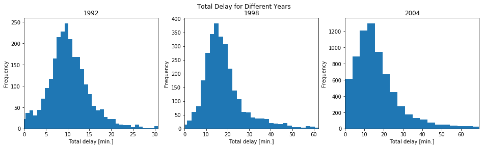

```python
def hist_total_delay(frame, ax):
    mean = frame.groupby('FlightNum').mean()
    mean['TotalDelay'].plot.hist(ax = ax, bins = 100)
    ax.set_xlim([0, mean['TotalDelay'].quantile(0.99)])
    ax.set_xlabel('Total delay [min.]')
plot_per_year(hist_total_delay, 'Total Delay for Different Years')
```

## Total Delay vs. Distance

- `Total delay` doesn't indicate a significant growth when `Distance` increases (averaged per `Flight Number`)
- (basically they are independent which can be also verified quantitatively by any kind of indepence test, such as chi-square, Kolmogorov-Smirnov, etc.)
- the spread of `Total delay` per `Distance` significantly increased in 2004 in comparison with 1992 and 1998 (most likely due to increase of flights number), but the average value is similar

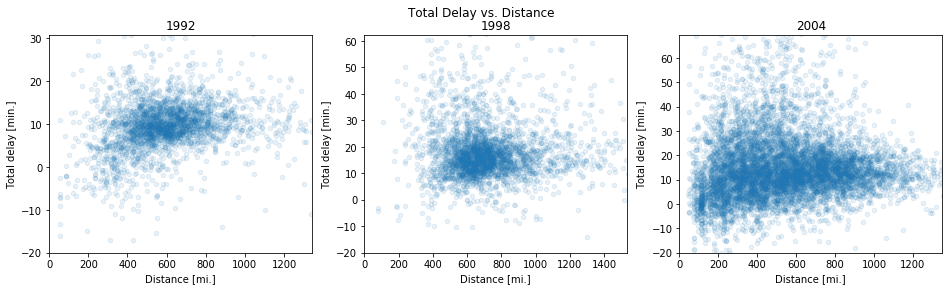

```python
def scatter_total_delay_vs_distance(frame, ax):
    mean = frame.groupby('FlightNum').mean()
    mean.plot.scatter(x = 'Distance', y = 'TotalDelay',
                      ylim = [-20, mean['TotalDelay'].quantile(0.99)],
                      xlim = [0, mean['Distance'].quantile(0.99)],
                      alpha = 0.1, ax = ax)
    ax.set_xlabel('Distance [mi.]')
    ax.set_ylabel('Total delay [min.]')
plot_per_year(scatter_total_delay_vs_distance, 'Total Delay vs. Distance')
```

## Total Delay vs. Month

- `Total delay` averaged per month peaks on summer vacation period and in December
- Each year it doesn't increase much, though the number of flights has increased significantly in the period between 1992 and 2004
- The spread of `Total delay` is increasing from 1992 to 2004

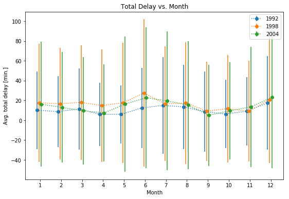

```python
fig, ax = plt.subplots(figsize = [9, 6])
step = 0.1
shift = -len(frames)/2*step
for year, frame in frames.items():
    mean = frame.groupby('Month')['TotalDelay'].mean()
    std = frame.groupby('Month')['TotalDelay'].std()
    plt.errorbar(np.arange(1 + shift, 13 + shift), mean, std, fmt = ':o')
    shift += step
plt.xlabel('Month')
plt.ylabel('Avg. total delay [min.]')
plt.xticks(range(1, 13))
plt.legend(frames.keys())
plt.title('Total Delay vs. Month')
plt.show()

# Note: seaborn pointplot doesn't work here due to huge amount of data
```

## Check Overestimation of Flight Duration Resulting Decrease of Delays

- we check the assumption of article [1] in our conditions
- 99% of flights have distances below 1500 miles, and estimated time for them is similar if you compare 1992, 1998 and 2004
- the delay is not correlated with distance in any of those years (which is obvious, because the estimated time is linear dependant on distance, and we have already seen that delay isn't correlated with it
- both parts of the assumption on our dataset are false: there's no overestimation for 99% of the flights, and the estimated time doesn't relate to delay at all
- the assumption of the article is false on our dataset

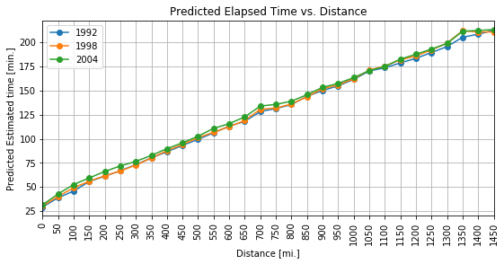

```python
fig, ax = plt.subplots(figsize = [9, 4])
for frame in frames.values():
    f = frame.loc[frame['Distance'] < 1500]
    f.loc[f['Distance'] < 1500] \
    .groupby(pd.cut(f['Distance'], 30))['CRSElapsedTime'] \
    .mean().plot(x = 'Distance', y = 'CRSElapsedTime', rot = 90, marker = 'o', grid = True)
plt.legend(frames.keys())
plt.xticks(range(0, 30), range(0, 1500, 1500 // 30))
plt.xlabel('Distance [mi.]')
plt.ylabel('Predicted Estimated time [min.]')
plt.title('Predicted Elapsed Time vs. Distance')
plt.show()
```

[figure not shown]

```python
def scatter_total_delay_vs_time(frame, ax):
    mean = frame.groupby('FlightNum').mean()
    mean.plot.scatter(x = 'Distance', y = 'TotalDelay',
                      ylim = [-20, mean['TotalDelay'].quantile(0.99)],
                      xlim = [0, mean['Distance'].quantile(0.99)],
                      alpha = 0.1, ax = ax)
    ax.set_xlabel('Predicted elapsed time [min.]')
    ax.set_ylabel('Total delay [min.]')
plot_per_year(scatter_total_delay_vs_time, 'Total Delay vs. Predicted Elapsed Time')
```

## References

[1] https://www.npr.org/2018/02/20/587195947/hidden-brain-airline-delays?t=1553068598087&t=1553979166718